# Ch 10 Exercises

#### a

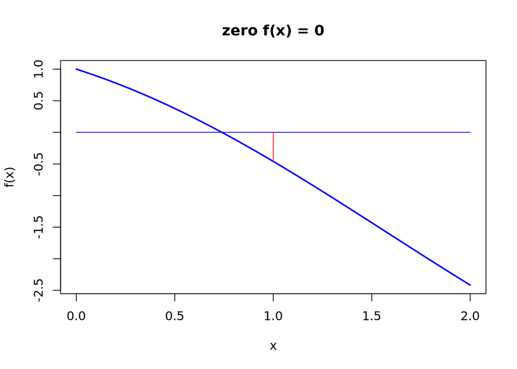

```
## last x value NA  continue (y or n)?
```

```
## [1] NA
```

```r
newtonraphson_show(f_ch10_ex5_a,1)
```

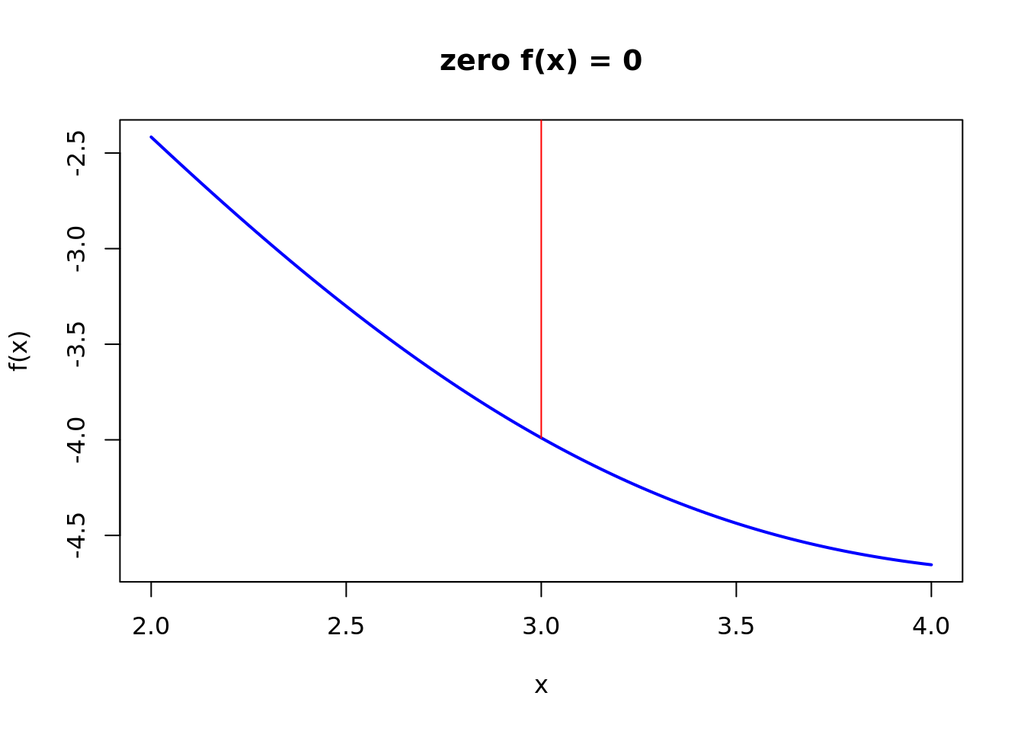

```
## last x value NA  continue (y or n)?
```

```
## [1] NA
```

```r
newtonraphson_show(f_ch10_ex5_a,3)
```

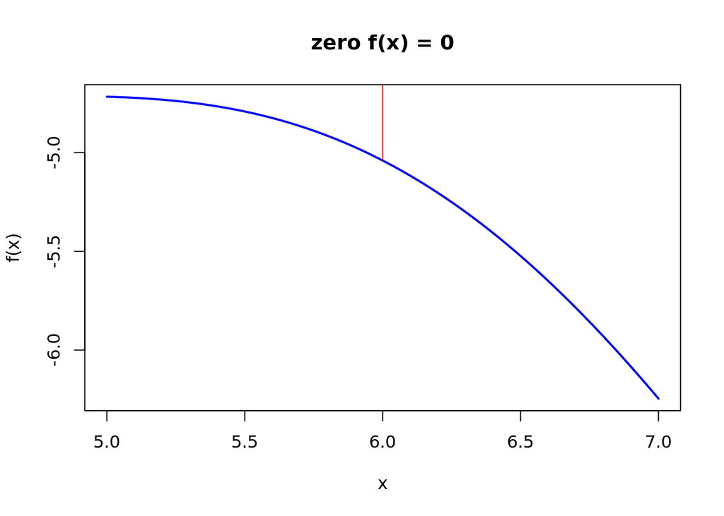

```
## last x value NA  continue (y or n)?
```

```
## [1] NA
```

```r
newtonraphson_show(f_ch10_ex5_a,6)
```

#### b

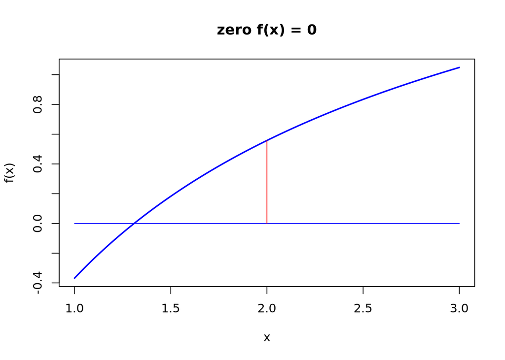

```
## last x value NA  continue (y or n)?
```

```
## [1] NA
```

```r
newtonraphson_show(f_ch10_ex5_b,2)
```

#### c

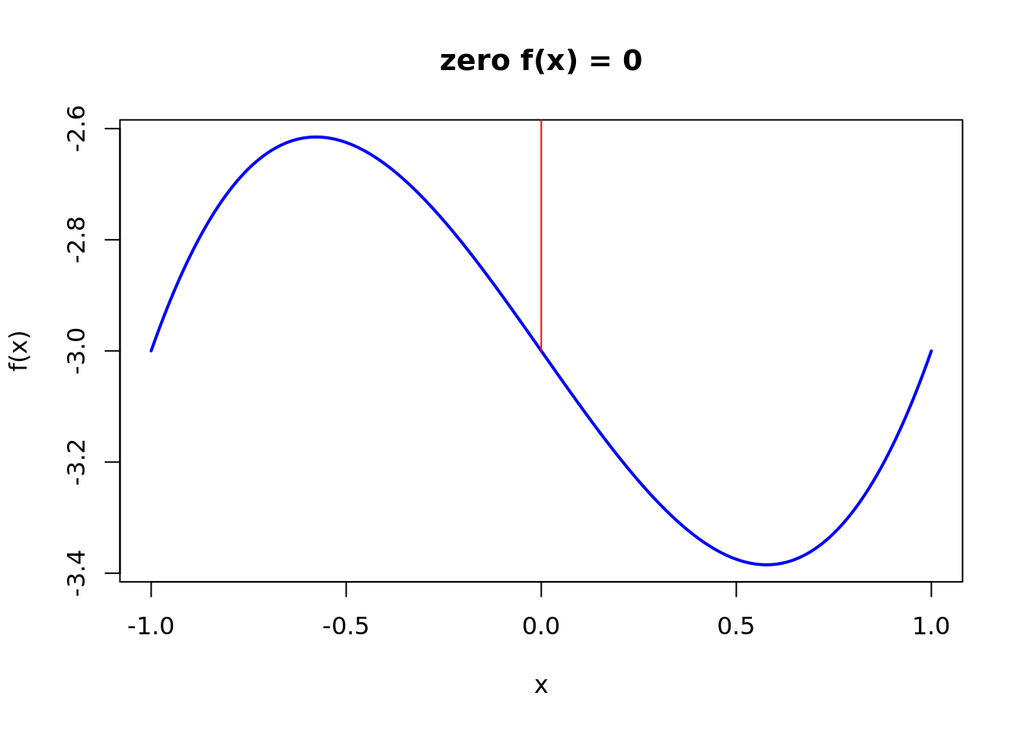

```
## last x value NA  continue (y or n)?
```

```
## [1] NA
```

```r
newtonraphson_show(f_ch10_ex5_c,0)
```

#### d

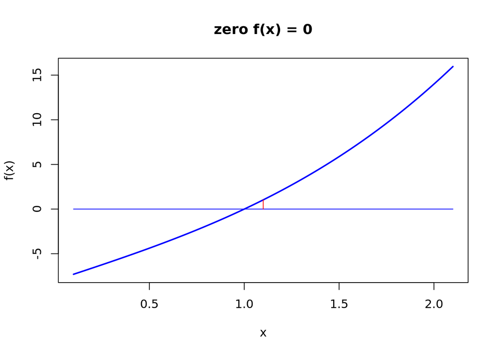

```
## last x value NA  continue (y or n)?
```

```
## [1] NA
```

```r
newtonraphson_show(f_ch10_ex5_d,1.1)
```

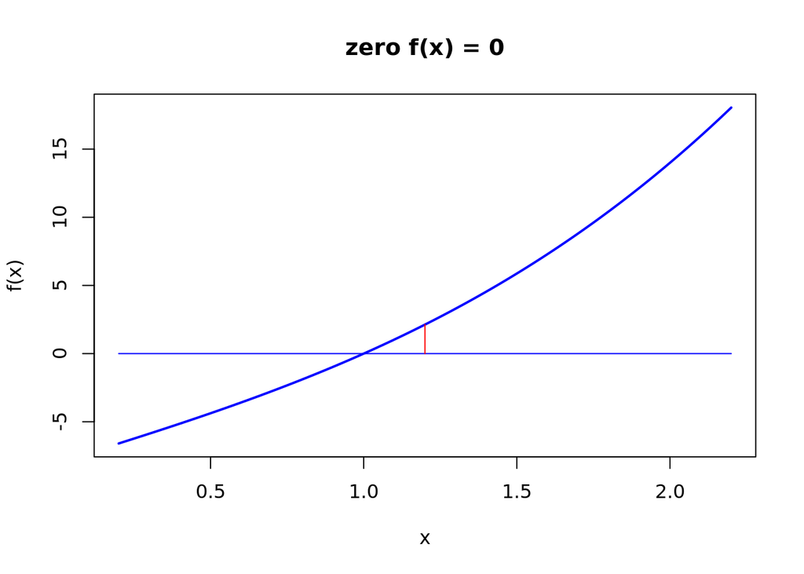

```
## last x value NA  continue (y or n)?
```

```
## [1] NA
```

```r
newtonraphson_show(f_ch10_ex5_d,1.2)
```

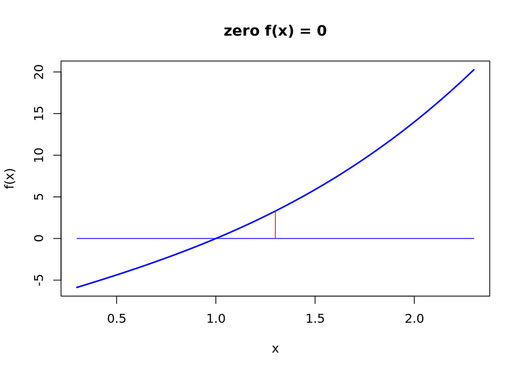

```
## last x value NA  continue (y or n)?
```

```
## [1] NA
```

```r
newtonraphson_show(f_ch10_ex5_d,1.3)
```

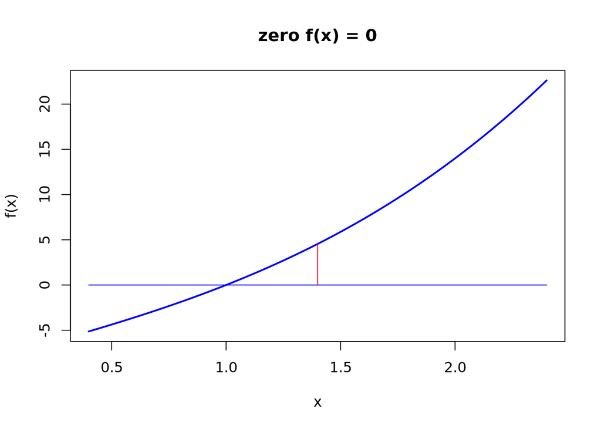

```
## last x value NA  continue (y or n)?
```

```
## [1] NA
```

```r
newtonraphson_show(f_ch10_ex5_d,1.4)
```

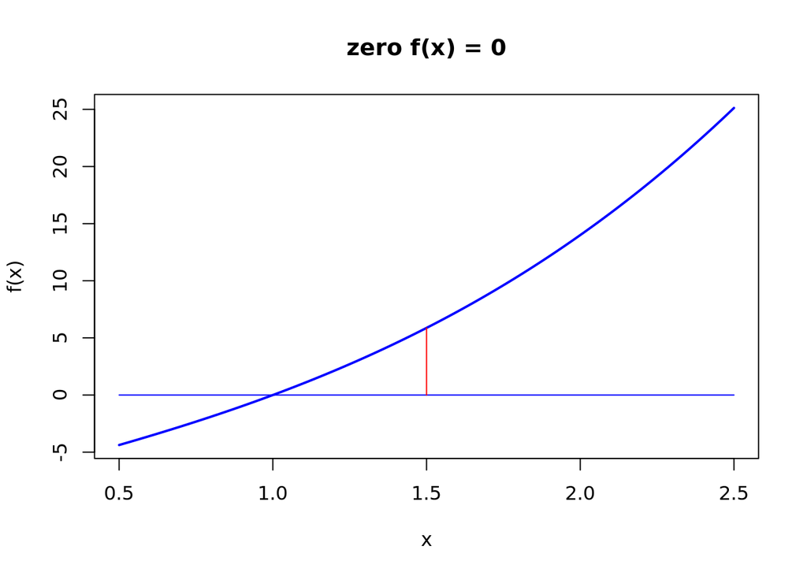

```
## last x value NA  continue (y or n)?
```

```
## [1] NA
```

```r
newtonraphson_show(f_ch10_ex5_d,1.5)
```

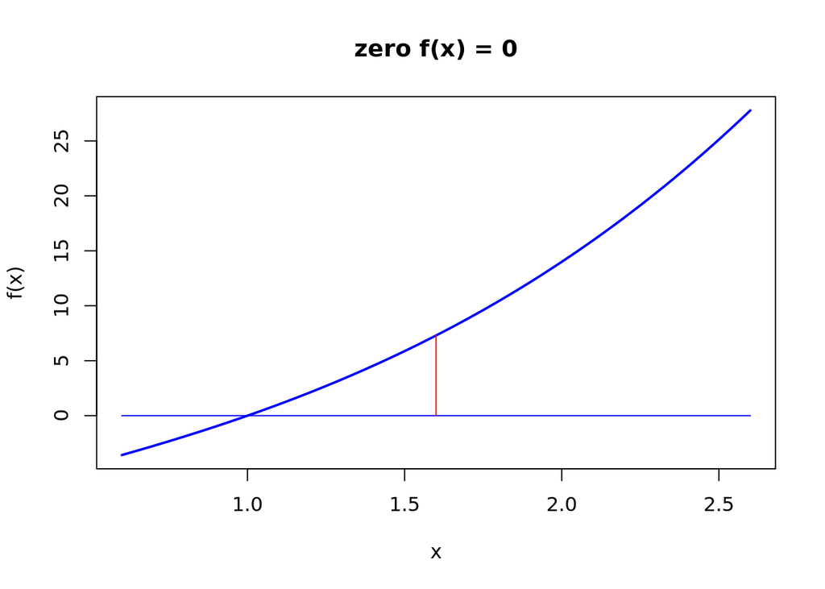

```
## last x value NA  continue (y or n)?
```

```
## [1] NA
```

```r
newtonraphson_show(f_ch10_ex5_d,1.6)
```

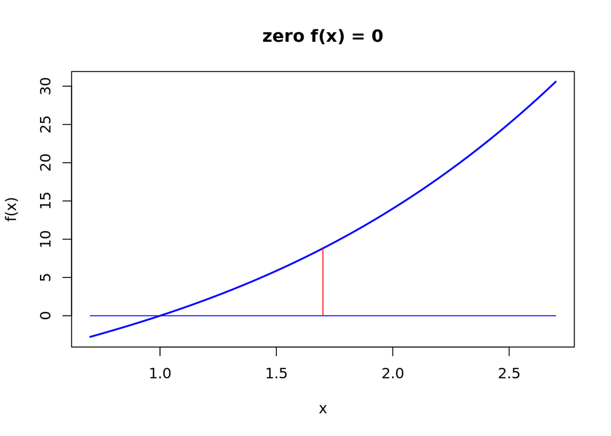

```
## last x value NA  continue (y or n)?
```

```
## [1] NA
```

```r
newtonraphson_show(f_ch10_ex5_d,1.7)
```

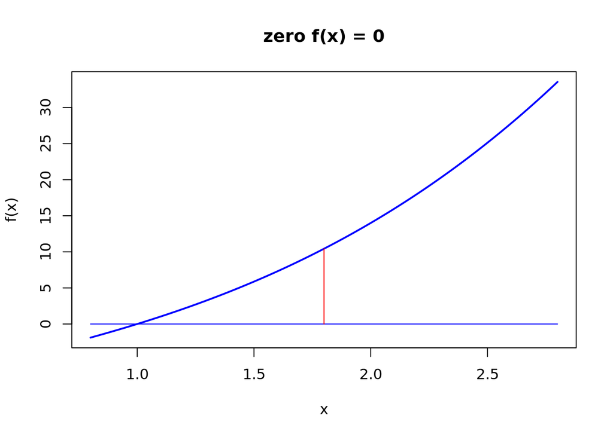

```
## last x value NA  continue (y or n)?
```

```
## [1] NA
```

```r
newtonraphson_show(f_ch10_ex5_d,1.8)
```

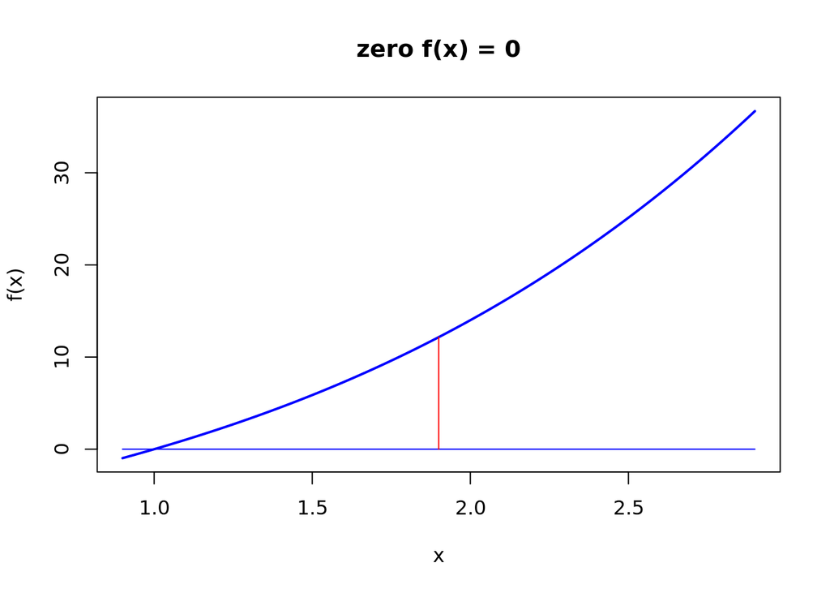

```
## last x value NA  continue (y or n)?
```

```
## [1] NA
```

```r
newtonraphson_show(f_ch10_ex5_d,1.9)
```

#### e

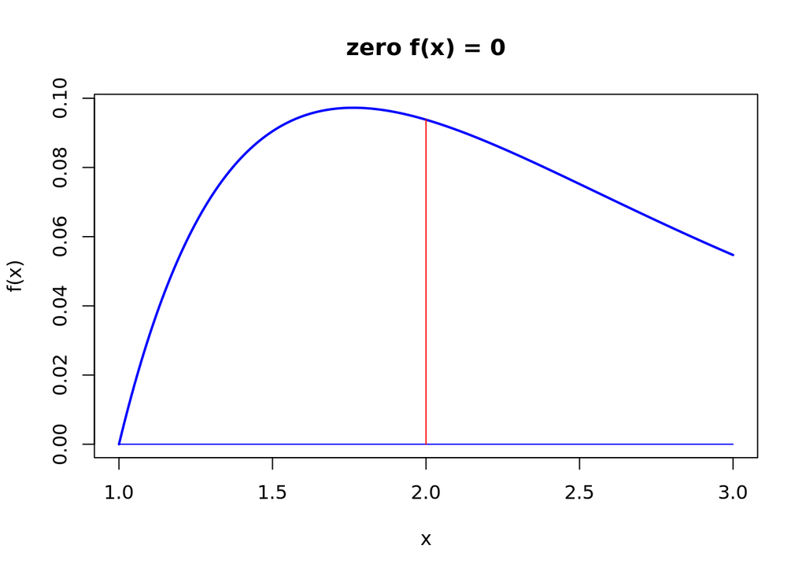

```
## last x value NA  continue (y or n)?
```

```
## [1] NA
```

```r
newtonraphson_show(f_ch10_ex5_e,2)
```

## 7

**Adaptive fixed-point iteration.**

**to find a root of a of f we can apply the fixed-point method to g(x) = x+cf(x), where c is some non-zero constant. That is, guven x- we put** $x_{n+1}=g(x_n)=x_n+cf(x_n)$

**from Taylor’s theorem we have**
$$g(x) \approx g(a) + (x-a)g'(a)
=a+(x-a)(a+cf'a(a))$$

**so**

$g(x)-a\approx(x-a)(1+cf'a(a))$

**BAsed on this approximation, explain why $\frac{-1}{f'(a)}$ would be a good choice for c.** **In practice we don’t know a so cannont find** $\frac{-1}{f'(a)}$. **AS step n of the iteration, what would be your best guess at** $\frac{-1}{f'(a)}$**? Using this guess for c, what happens to the fixed-point method?**

## 9

**for f:R->R, the Newton-Raphson algorithm uses a sequence of linear approximations to f to find a root. What happens if we use quadratic approximation instead**

**Suppose that xn is our current approximation to f; then aquadratic approximation to f at xn is given by the second order Taylor expansion:**
$$f(x)\approx g_n(x)=f(x_n)+(x-x_n)f'(x_n)+\frac{1}{2}(x-x_n)^2f''(x_n)$$
**let** $x_{n+1}$ **be the solution of** $g_n(x)=0$ **that is closest to xn, assuming a soluton existgs. if** $g_n(x)=0$ **has no solution, then let** $x_{n+1}$ ** be the point at which gn attains either its minimum or maximum. Figure 10.5 illustrates the two cases.**

**implement this algorithm in R and use it to find the fixed points of teh following functions:**

*a) ccos(x)-x using x0 = 1,3,6*  
*b) log(x)-exp(-x) using x0=2*  
*c)* $x^3-x-3$* using x0=0*  
*d)* $x^3-7x^2+14x-8$* using x0=1.1,1.2,…,1.9*  
*e) log(x)exp(-c) using x0 = 2*

**for your implemntation, assume that you are given a function FTN(x) that returns the vector (f(x),f’(x),f’’(x)). Given xn, if you rewrtie gn as** $g_n(x)=a_2x^2+a_1x+a_0$ **then you can use the quadratic formula to the find the roots of gn and thus xN+1. If gn hs no roots then the min/max occura the point g’n(x)=)**

**How does this algorithm compare to the Newton-Raphoson algorithem, or to Halley’s method (ex 11)**

## 11

**The astronomer Edmund Halley devised a root finding method faster than the Newton-Raphson method, but which requires second derivative infromation. if xn is our current solution then:**
$$x_{n+1}=x_n - \frac{f(x_n)}{f'(x_n)-(\frac{f(x_n)f''(x_n)}{2f'(x_n)})}$$

**let m be the postiive integer. Show that applying Halley’s method to the function** $f(x)=x^m-k$ **gives**
$$x_{n+1} = \frac{(m-1)x^m_n + (m+1)k}{(m+1)x^m_n + (m-1)k}x_n$$

**use this to show that, to 0 decimal places,** $59^{\frac{1}{7}}$**=1.790518691**